# DRD_2026_Lesson_2

First of all, let’s clean the workspace and set our the working directory:

```r
rm(list=ls())
setwd("~/Dropbox/DRD_2026/2")
```

# CHUNK1: upload the manifest and explore it

The Illumina 450k manifest has been downloaded from this link: http://support.illumina.com/array/array_kits/infinium_humanmethylation450_beadchip_kit/downloads.html

The csv file is quite large (200 MB). It is a good idea to import in R just the first 20 rows of the file to check that everything is ok. To this aim, we set the nrows argument=20. As this file is a csv, we will use the comma as separator.

```r
Illumina450Manifest <- read.table("HumanMethylation450_15017482_v1-2.csv",sep=",",header=T, nrows=20)
```

```
## Error in `scan()`:
## ! line 7 did not have 27 elements
```

There are some problems :-(

Let’s try to use the readLines() function to check the first lines of the file. You will see that the problem is that the first 7 lines of the file are a sort of header, and that the spreadheet actually starts from the 8th line. Now we try to import again the file skipping the first 7 lines (argument skip=7). Furtheremore, we will set stringsAsFactors = T.

```r
readLines("HumanMethylation450_15017482_v1-2.csv",n=20)
```

```
##  [1] "Illumina, Inc.,,,,,,,,,,,,,,,,,,,,,,,,,"
##  [2] "[Heading],,,,,,,,,,,,,,,,,,,,,,,,,,"
##  [3] "Descriptor File Name,BS0010894-AQP_content.bpm,,,,,,,,,,,,,,,,,,,,,,,,,"
##  [4] "Assay Format,Infinium 2,,,,,,,,,,,,,,,,,,,,,,,,,"
##  [5] "Date Manufactured,6/11/2008,,,,,,,,,,,,,,,,,,,,,,,,,"
##  [6] "Loci Count ,485553,,,,,,,,,,,,,,,,,,,,,,,,,"
##  [7] "[Assay],,,,,,,,,,,,,,,,,,,,,,,,,,"
##  [8] "IlmnID,Name,AddressA_ID,AlleleA_ProbeSeq,AddressB_ID,AlleleB_ProbeSeq,Infinium_Design_Type,Next_Base,Color_Channel,Forward_Sequence,Genome_Build,CHR,MAPINFO,SourceSeq,Chromosome_36,Coordinate_36,Strand,Probe_SNPs,Probe_SNPs_10,Random_Loci,Methyl27_Loci,UCSC_RefGene_Name,UCSC_RefGene_Accessi…
##  [9] "cg00035864,cg00035864,31729416,AAAACACTAACAATCTTATCCACATAAACCCTTAAATTTATCTCAAATTC,,,II,,,AATCCAAAGATGATGGAGGAGTGCCCGCTCATGATGTGAAGTACCTGCTCAGCTGGAAAC[CG]AATTTGAGATAAATTCAAGGGTCTATGTGGACAAGACTGCTAGTGTCTCTCTCTGGATTG,37,Y,8553009,AGACACTAGCAGTCTTGTCCACATAGACCCTTGAATTTATCTCAAATTCG,Y,8613009,F,,…
## [10] "cg00050873,cg00050873,32735311,ACAAAAAAACAACACACAACTATAATAATTTTTAAAATAAATAAACCCCA,31717405,ACGAAAAAACAACGCACAACTATAATAATTTTTAAAATAAATAAACCCCG,I,A,Red,TATCTCTGTCTGGCGAGGAGGCAACGCACAACTGTGGTGGTTTTTGGAGTGGGTGGACCC[CG]GCCAAGACGGCCTGGGCTGACCAGAGACGGGAGGCAGAAAAAGTGGGCAGGTGGTTGCAG,37,Y,9363356,CGG…
## [11] "cg00061679,cg00061679,28780415,AAAACATTAAAAAACTAATTCACTACTATTTAATTACTTTATTTTCCATC,,,II,,,TCAACAAATGAGAGACATTGAAGAACTAATTCACTACTATTTGGTTACTTTATTTTCCAT[CG]AAGAAAACCTCTTTTTAAAAACTAACACATAAATAAAATGAACGAAGAACAAACTAAACG,37,Y,25314171,CGATGGAAAATAAAGTAACCAAATAGTAGTGAATTAGTTCTTCAATGTCT,Y,23723559,R…
## [12] "cg00063477,cg00063477,16712347,TATTCTTCCACACAAAATACTAAACRTATATTTACAAAAATACTTCCATC,,,II,,,CTCCTGTACTTGTTCATTAAATAATGATTCCTTGGATATACCAAGTCTGGATAGCGGATT[CG]ATGGAAGCATTTTTGTAAATATACGTTCAGTATTTTGTGTGGAAGAACACAATCTAGCTG,37,Y,22741795,CGATGGAAGCATTTTTGTAAATATACGTTCAGTATTTTGTGTGGAAGAAC,Y,21151183,F…
## [13] "cg00121626,cg00121626,19779393,AAAACTAATAAAAATAACTTACAAACCAAATACTATACCCTACAACTCTC,,,II,,,AGGTGAATGAAGAGACTAATGGGAGTGGCTTGCAAGCCAGGTACTGTGCCCTACAACTCT[CG]CGCTGCCACAAAAAGCCAATTAACGAAGCAAACTGTTTTATCTTTTCCTCTCCCCAGAAG,37,Y,21664296,AGACTAATGGGAGTGGCTTGCAAGCCAGGTACTGTGCCCTACAACTCTCG,Y,20123684,R…
## [14] "cg00212031,cg00212031,29674443,CCCAATTAACCACAAAAACTAAACAAATTATACAATCAAAAAAACATACA,38703326,CCCAATTAACCGCAAAAACTAAACAAATTATACGATCGAAAAAACGTACG,I,T,Red,CCATTGGCCCGCCCCAGTTGGCCGCAGGGACTGAGCAAGTTATGCGGTCGGGAAGACGTG[CG]TTAAAGGGCTGAAGGGGAGGGACGGAACTGACAGTCTCTGTGACAGCTCTGAGGTGGGAG,37,Y,21239348,CG…
## [15] "cg00213748,cg00213748,30703409,TTTTAACACCTAACACCATTTTAACAATAAAAATTCTACAAAAAAAAACA,36767301,TTTTAACGCCTAACACCGTTTTAACGATAAAAATTCTACAAAAAAAAACG,I,A,Red,TCTGTGGGACCATTTTAACGCCTGGCACCGTTTTAACGATGGAGGTTCTGCAGGAGGGGG[CG]ACCTGGGGTAGGAGGCGTGCTAGTGGTGGATGACATTGTGGCAGAGATGGAGGTGGTGGC,37,Y,8148233,CGC…
## [16] "cg00214611,cg00214611,69792329,CTAACTTCCAAACCACACTTTATATACTAAACTACAATATAACACAAACA,46723459,CTAACTTCCGAACCGCGCTTTATATACTAAACTACAATATAACGCGAACG,I,A,Red,GCGCCGGCAGGACTAGCTTCCGGGCCGCGCTTTGTGTGCTGGGCTGCAGTGTGGCGCGGG[CG]AGGAAGCTGGTAGGGCGGTTGTCGCAAGCTCCAGCTGCAGCCTCCGCCTACGTGAGAAGA,37,Y,15815688,CG…
## [17] "cg00223952,cg00223952,17691457,TTAACTATACAAAAAAATCTCTCCCTTTAAAAAATACAACCAACTTCAAC,,,II,,,TTTCCCCGACATTGGCTGTGCAAAAAGGTCTCTCCCTTTAAAGGGTACAGCCAGCTTCAG[CG]AGGCTGAGGGAAACTCTAAGGTTGGGGCGGGTGTTGACAAAAGAGCACGTCCCGGACTCC,37,Y,4868996,CGCTGAAGCTGGCTGTACCCTTTAAAGGGAGAGACCTTTTTGCACAGCCA,Y,4928996,R,,…
## [18] "cg00243321,cg00243321,36709370,AATACRAAATCTACRAATCCAACRAAAATCCTCAAAAAACCTAAATCCAC,,,II,,,AGACCCGCTCCCTGCAAGACCCACGGGCGTCGCCCTGCTGAGAACCTGGTCCCACACCTA[CG]TGGACCCAGGTTTCCTGAGGACCTCCGCTGGACCCGCAGATCCCGCACTGGCCAAAGGGC,37,Y,6133740,CGTGGACCCAGGTTTCCTGAGGACCTCCGCTGGACCCGCAGATCCCGCAC,Y,6193740,F,,…
## [19] "cg00271873,cg00271873,11808416,CRCCAAATTTATTCAAACTTCTACAATCTCCCAAATTTTCAAACTTATCC,,,II,,,TTCCTGTCCGACGCCAGGTTTGTTCAGGCTTCTGCAGTCTCCCAAGTTTTCAGGCTTGTC[CG]ACACTTCTTGACTGAAGAATGATAATGTTTTTGGTAAGACTGTGCCACTGACAGATGATC,37,Y,14649908,CGGACAAGCCTGAAAACTTGGGAGACTGCAGAAGCCTGAACAAACCTGGC,Y,13159918,R…
## [20] "cg00272582,cg00272582,73678371,AAATCTAAAAACCTACAACAATAAAATCTATCRCCTTAACTAAAACTAAC,,,II,,,ACTGAGGGCGGGGGTCTAAGGGCCTGCAACAATGAGATCTGTCGCCTTGGCTAGGACTGG[CG]CCGAGAGGCGATAGGTCTCGGGAGAGCCTGGCGCAGGGTGTGGGAGATTAGGAATCCCAG,37,Y,2802965,GGTCTAAGGGCCTGCAACAATGAGATCTGTCGCCTTGGCTAGGACTGGCG,Y,2862965,R,,…
```

```r
Illumina450Manifest <- read.table("HumanMethylation450_15017482_v1-2.csv",sep=",",header=T, nrows=20, skip=7, stringsAsFactors = T)
dim(Illumina450Manifest)
```

```
## [1] 20 33
```

```r
head(Illumina450Manifest)
```

```
##       IlmnID       Name AddressA_ID
## 1 cg00035864 cg00035864    31729416
## 2 cg00050873 cg00050873    32735311
## 3 cg00061679 cg00061679    28780415
## 4 cg00063477 cg00063477    16712347
## 5 cg00121626 cg00121626    19779393
## 6 cg00212031 cg00212031    29674443
##                                     AlleleA_ProbeSeq AddressB_ID
## 1 AAAACACTAACAATCTTATCCACATAAACCCTTAAATTTATCTCAAATTC          NA
## 2 ACAAAAAAACAACACACAACTATAATAATTTTTAAAATAAATAAACCCCA    31717405
## 3 AAAACATTAAAAAACTAATTCACTACTATTTAATTACTTTATTTTCCATC          NA
## 4 TATTCTTCCACACAAAATACTAAACRTATATTTACAAAAATACTTCCATC          NA
## 5 AAAACTAATAAAAATAACTTACAAACCAAATACTATACCCTACAACTCTC          NA
## 6 CCCAATTAACCACAAAAACTAAACAAATTATACAATCAAAAAAACATACA    38703326
##                                     AlleleB_ProbeSeq Infinium_Design_Type
```

[output cut: 62 more lines]

```r
str(Illumina450Manifest)
```

```
## 'data.frame':    20 obs. of  33 variables:
##  $ IlmnID                     : Factor w/ 20 levels "cg00035864","cg00050873",..: 1 2 3 4 5 6 7 8 9 10 ...
##  $ Name                       : Factor w/ 20 levels "cg00035864","cg00050873",..: 1 2 3 4 5 6 7 8 9 10 ...
##  $ AddressA_ID                : int  31729416 32735311 28780415 16712347 19779393 29674443 30703409 69792329 36709370 11808416 ...
##  $ AlleleA_ProbeSeq           : Factor w/ 20 levels "AAAACACTAACAATCTTATCCACATAAACCCTTAAATTTATCTCAAATTC",..: 1 10 2 19 4 14 20 17 8 15 ...
##  $ AddressB_ID                : int  NA 31717405 NA NA NA 38703326 36767301 46723459 NA NA ...
##  $ AlleleB_ProbeSeq           : Factor w/ 6 levels "","AACTCTAAACTACCCGACACAAACTCCAAAAACTTCTCGAAAAAAACTCG",..: 1 3 1 1 1 4 6 5 1 1 ...
##  $ Infinium_Design_Type       : Factor w/ 2 levels "I","II": 2 1 2 2 2 1 1 1 2 2 ...
##  $ Next_Base                  : Factor w/ 3 levels "","A","T": 1 2 1 1 1 3 2 2 1 1 ...
##  $ Color_Channel              : Factor w/ 2 levels "","Red": 1 2 1 1 1 2 2 2 1 1 ...
##  $ Forward_Sequence           : Factor w/ 20 levels "AAAGTTCTTTTTGCTTCCTGAAATTTCCGGCAGCCAAAAGATCTATAGCGAGTGGCAGTC[CG]ATCCAGCAAGAGCCAATGAAAGATCCACTCCACAGTGAAGAAGGACATGCAGATGAAGTG",..: 3 15 16 10 7 8 18 14 5 20 ...
##  $ Genome_Build               : int  37 37 37 37 37 37 37 37 37 37 ...
##  $ CHR                        : Factor w/ 1 level "Y": 1 1 1 1 1 1 1 1 1 1 ...
##  $ MAPINFO                    : int  8553009 9363356 25314171 22741795 21664296 21239348 8148233 15815688 6133740 14649908 ...
##  $ SourceSeq                  : Factor w/ 20 levels "ACCTACCGGGTGCCATAGAGGCTGCGGCAGGGTTCCTGTGGCTTGGGTCG",..: 2 15 5 6 3 8 10 11 17 13 ...
```

[output cut: 19 more lines]

You can also use the read.csv function, which uses the comma as default separator

```r
?read.csv
Illumina450Manifest <- read.csv("HumanMethylation450_15017482_v1-2.csv",header=T, nrows=20,skip=7,stringsAsFactors = T)
head(Illumina450Manifest)
```

```
##       IlmnID       Name AddressA_ID
## 1 cg00035864 cg00035864    31729416
## 2 cg00050873 cg00050873    32735311
## 3 cg00061679 cg00061679    28780415
## 4 cg00063477 cg00063477    16712347
## 5 cg00121626 cg00121626    19779393
## 6 cg00212031 cg00212031    29674443
##                                     AlleleA_ProbeSeq AddressB_ID
## 1 AAAACACTAACAATCTTATCCACATAAACCCTTAAATTTATCTCAAATTC          NA
## 2 ACAAAAAAACAACACACAACTATAATAATTTTTAAAATAAATAAACCCCA    31717405
## 3 AAAACATTAAAAAACTAATTCACTACTATTTAATTACTTTATTTTCCATC          NA
## 4 TATTCTTCCACACAAAATACTAAACRTATATTTACAAAAATACTTCCATC          NA
## 5 AAAACTAATAAAAATAACTTACAAACCAAATACTATACCCTACAACTCTC          NA
## 6 CCCAATTAACCACAAAAACTAAACAAATTATACAATCAAAAAAACATACA    38703326
##                                     AlleleB_ProbeSeq Infinium_Design_Type
```

[output cut: 62 more lines]

```r
str(Illumina450Manifest)
```

```
## 'data.frame':    20 obs. of  33 variables:
##  $ IlmnID                     : Factor w/ 20 levels "cg00035864","cg00050873",..: 1 2 3 4 5 6 7 8 9 10 ...
##  $ Name                       : Factor w/ 20 levels "cg00035864","cg00050873",..: 1 2 3 4 5 6 7 8 9 10 ...
##  $ AddressA_ID                : int  31729416 32735311 28780415 16712347 19779393 29674443 30703409 69792329 17691457 36709370 ...
##  $ AlleleA_ProbeSeq           : Factor w/ 20 levels "AAAACACTAACAATCTTATCCACATAAACCCTTAAATTTATCTCAAATTC",..: 1 10 2 18 4 13 20 16 19 8 ...
##  $ AddressB_ID                : int  NA 31717405 NA NA NA 38703326 36767301 46723459 NA NA ...
##  $ AlleleB_ProbeSeq           : Factor w/ 6 levels "","AACTCTAAACTACCCGACACAAACTCCAAAAACTTCTCGAAAAAAACTCG",..: 1 3 1 1 1 4 6 5 1 1 ...
##  $ Infinium_Design_Type       : Factor w/ 2 levels "I","II": 2 1 2 2 2 1 1 1 2 2 ...
##  $ Next_Base                  : Factor w/ 3 levels "","A","T": 1 2 1 1 1 3 2 2 1 1 ...
##  $ Color_Channel              : Factor w/ 2 levels "","Red": 1 2 1 1 1 2 2 2 1 1 ...
##  $ Forward_Sequence           : Factor w/ 20 levels "AAAGTTCTTTTTGCTTCCTGAAATTTCCGGCAGCCAAAAGATCTATAGCGAGTGGCAGTC[CG]ATCCAGCAAGAGCCAATGAAAGATCCACTCCACAGTGAAGAAGGACATGCAGATGAAGTG",..: 2 14 15 9 6 7 17 13 20 4 ...
##  $ Genome_Build               : int  37 37 37 37 37 37 37 37 37 37 ...
##  $ CHR                        : Factor w/ 1 level "Y": 1 1 1 1 1 1 1 1 1 1 ...
##  $ MAPINFO                    : int  8553009 9363356 25314171 22741795 21664296 21239348 8148233 15815688 4868996 6133740 ...
##  $ SourceSeq                  : Factor w/ 20 levels "ACCTACCGGGTGCCATAGAGGCTGCGGCAGGGTTCCTGTGGCTTGGGTCG",..: 2 15 5 6 3 8 10 11 12 17 ...
```

[output cut: 19 more lines]

The descriptions of the Manifest Column Headings can be found here: https://support.illumina.com/content/dam/illumina-support/documents/downloads/productfiles/methylationepic/infinium-methylationepic-manifest-column-headings.pdf. In summary:

IlmnID: Unique CpG locus identifier from the Illumina CG database

Name: Unique CpG locus identifier from the Illumina CG database

AddressA_ID: Address of probe A

AlleleA_ProbeSeq: Sequence for probe A

AddressB_ID: Address of probe B - Infinium I assays only

AlleleB_ProbeSeq: Sequence for probe B - Infinium I assays only

Infinium_Design_Type: Defines Assay type - Infinium I or Infinium II

Next_Base: Base added at SBE step - Infinium I assays only

Color_Channel: Color of the incorporated base (Red or Green) - Infinium I assays only

Forward_Sequence: Sequence (in 5’-3’ orientation) flanking query site

Genome_Build: Genome build on which forward sequence is based

CHR: Chromosome - genome build 37

MAPINFO: Coordinates - genome build 37

SourceSeq: Unconverted design sequence

Chromosome_36: Chromosome - genome build 36

Coordinate_36: Coordinates - genome build 36

Strand: Design strand

Probe_SNPs: Assays with SNPs present within probe >10bp from query site

Probe_SNPs_10: Assays with SNPs present within probe ≤10bp from query site (HM27 carryover or recently discovered)

Random_Loci: Loci which were chosen randomly in the design proccess

Methyl27_Loci: Present or absent on HumanMethylation27 array

UCSC_RefGene_Name: Gene name (UCSC)

UCSC_RefGene_Accession: Accession number (UCSC)

UCSC_RefGene_Group: Gene region feature category (UCSC)

UCSC_CpG_Islands_Name: CpG island name (UCSC)

Relation_to_UCSC_CpG_Island: Relationship to Canonical CpG Island: Shores - 0-2 kb from CpG island; Shelves - 2-4 kb from CpG island.

Phantom: FANTOM-derived promoter

DMR: Differentially methylated region (experimentally determined)

Enhancer: Enhancer element (informatically-determined)

HMM_Island: Hidden Markov Model Island

Regulatory_Feature_Name: Regulatory feature (informatically determined)

Regulatory_Feature_Group: Regulatory feature category

DHS: DNAse hypersensitive site (experimentally determined)

Now we can upload the whole manifest. This step can take some minutes, if you encounter problems you can skip the next two command lines and directly go to “Load the Illumina450Manifest.RData”:

```r
Illumina450Manifest <- read.csv("HumanMethylation450_15017482_v1-2.csv",header=T, skip=7, stringsAsFactors = T)
save(Illumina450Manifest,file="Illumina450Manifest.RData")
```

Remember that if you save your data with save(), it cannot be restored under different name. The original object name will be automatically used when you will load the data.

Load the Illumina450Manifest.RData

```r
load("Illumina450Manifest.RData")
```

To know the name of the object that we have just uploaded, we can list the objects in the workspace:

```r
ls()
```

```
## [1] "Illumina450Manifest"
```

Let’s apply some exploratory functions:

```r
dim(Illumina450Manifest)
```

```
## [1] 486428     33
```

```r
head(Illumina450Manifest)
```

```
##       IlmnID       Name AddressA_ID
## 1 cg00035864 cg00035864    31729416
## 2 cg00050873 cg00050873    32735311
## 3 cg00061679 cg00061679    28780415
## 4 cg00063477 cg00063477    16712347
## 5 cg00121626 cg00121626    19779393
## 6 cg00212031 cg00212031    29674443
##                                     AlleleA_ProbeSeq AddressB_ID
## 1 AAAACACTAACAATCTTATCCACATAAACCCTTAAATTTATCTCAAATTC
## 2 ACAAAAAAACAACACACAACTATAATAATTTTTAAAATAAATAAACCCCA    31717405
## 3 AAAACATTAAAAAACTAATTCACTACTATTTAATTACTTTATTTTCCATC
## 4 TATTCTTCCACACAAAATACTAAACRTATATTTACAAAAATACTTCCATC
## 5 AAAACTAATAAAAATAACTTACAAACCAAATACTATACCCTACAACTCTC
## 6 CCCAATTAACCACAAAAACTAAACAAATTATACAATCAAAAAAACATACA    38703326
##                                     AlleleB_ProbeSeq Infinium_Design_Type
```

[output cut: 62 more lines]

```r
str(Illumina450Manifest)
```

```
## 'data.frame':    486428 obs. of  33 variables:
##  $ IlmnID                     : Factor w/ 486428 levels "[Controls]","10627500",..: 1743 2082 2315 2353 3658 5417 5451 5467 5662 6070 ...
##  $ Name                       : Factor w/ 485593 levels "","BISULFITE CONVERSION I",..: 895 1234 1467 1505 2810 4569 4603 4619 4814 5222 ...
##  $ AddressA_ID                : Factor w/ 485614 levels "","-99","10600322",..: 163955 171493 142506 49192 74497 146457 155290 448596 56107 200820 ...
##  $ AlleleA_ProbeSeq           : Factor w/ 486428 levels "","AAAAAAAAAAAAAAAAAACCACAAAAAAATCCCCACTCTAAAACCCCACA",..: 35018 143551 35762 428168 41002 296102 483734 335382 461498 128017 ...
##  $ AddressB_ID                : Factor w/ 135503 levels "","10600313",..: 1 45525 1 1 1 60142 56512 76868 1 1 ...
##  $ AlleleB_ProbeSeq           : Factor w/ 135502 levels "","AAAAAAAAAAAAAAAAAACCGCGAAAAAATCCCCGCTCTAAAACCCCGCG",..: 1 49675 1 1 1 77355 135117 95693 1 1 ...
##  $ Infinium_Design_Type       : Factor w/ 3 levels "","I","II": 3 2 3 3 3 2 2 2 3 3 ...
##  $ Next_Base                  : Factor w/ 4 levels "","A","C","T": 1 2 1 1 1 4 2 2 1 1 ...
##  $ Color_Channel              : Factor w/ 3 levels "","Grn","Red": 1 3 1 1 1 3 3 3 1 1 ...
##  $ Forward_Sequence           : Factor w/ 485513 levels "","AAAAAAAAAAAAAAAAAAAAAAAAAAAAAAATATGTCTGCTAAATAATCACAGAGTGAAA[CG]AAGAGGAAGAAACTAAAGTACAGTTTGGAACATAGTACAGTGCCCCTGGGTACTGAATCA",..: 25106 392559 395303 218896 81396 152102 421755 296780 478969 55952 ...
##  $ Genome_Build               : int  37 37 37 37 37 37 37 37 37 37 ...
##  $ CHR                        : Factor w/ 25 levels "","1","10","11",..: 25 25 25 25 25 25 25 25 25 25 ...
##  $ MAPINFO                    : int  8553009 9363356 25314171 22741795 21664296 21239348 8148233 15815688 4868996 6133740 ...
##  $ SourceSeq                  : Factor w/ 485344 levels "","AAAAAAAAAACCAACCCCAAACAAAAACCCTGTGCCCAGAATTGCATTCG",..: 28962 285897 116668 116692 29628 123295 148857 152724 189023 323598 ...
```

[output cut: 19 more lines]

```r
colnames(Illumina450Manifest)
```

```
##  [1] "IlmnID"                      "Name"
##  [3] "AddressA_ID"                 "AlleleA_ProbeSeq"
##  [5] "AddressB_ID"                 "AlleleB_ProbeSeq"
##  [7] "Infinium_Design_Type"        "Next_Base"
##  [9] "Color_Channel"               "Forward_Sequence"
## [11] "Genome_Build"                "CHR"
## [13] "MAPINFO"                     "SourceSeq"
## [15] "Chromosome_36"               "Coordinate_36"
## [17] "Strand"                      "Probe_SNPs"
## [19] "Probe_SNPs_10"               "Random_Loci"
## [21] "Methyl27_Loci"               "UCSC_RefGene_Name"
## [23] "UCSC_RefGene_Accession"      "UCSC_RefGene_Group"
## [25] "UCSC_CpG_Islands_Name"       "Relation_to_UCSC_CpG_Island"
## [27] "Phantom"                     "DMR"
## [29] "Enhancer"                    "HMM_Island"
## [31] "Regulatory_Feature_Name"     "Regulatory_Feature_Group"
## [33] "DHS"
```

```r
head(rownames(Illumina450Manifest))
```

```
## [1] "1" "2" "3" "4" "5" "6"
```

Let’s check the distribution of probes across the chromosomes

```r
table(Illumina450Manifest$CHR)
```

```
##
##           1    10    11    12    13    14    15    16    17    18    19     2
##   916 46857 24388 28794 24539 12285 15078 15259 21969 27879  5922 25521 34810
##    20    21    22     3     4     5     6     7     8     9     X     Y
## 10379  4243  8552 25159 20464 24327 36611 30017 20950  9861 11232   416
```

Remember that by default,factor levels are ordered according to alphabetical order (1,10,11, etc).

Remember that, to select the column CHR, you can write also:

```r
table(Illumina450Manifest[,"CHR"])
```

```
##
##           1    10    11    12    13    14    15    16    17    18    19     2
##   916 46857 24388 28794 24539 12285 15078 15259 21969 27879  5922 25521 34810
##    20    21    22     3     4     5     6     7     8     9     X     Y
## 10379  4243  8552 25159 20464 24327 36611 30017 20950  9861 11232   416
```

or

```r
table(Illumina450Manifest[,]$CHR)
```

```
##
##           1    10    11    12    13    14    15    16    17    18    19     2
##   916 46857 24388 28794 24539 12285 15078 15259 21969 27879  5922 25521 34810
##    20    21    22     3     4     5     6     7     8     9     X     Y
## 10379  4243  8552 25159 20464 24327 36611 30017 20950  9861 11232   416
```

or index it. From the result of the colnames function, we know that the column CHR is the 12th column, so you can write:

```r
table(Illumina450Manifest[,12])
```

```
##
##           1    10    11    12    13    14    15    16    17    18    19     2
##   916 46857 24388 28794 24539 12285 15078 15259 21969 27879  5922 25521 34810
##    20    21    22     3     4     5     6     7     8     9     X     Y
## 10379  4243  8552 25159 20464 24327 36611 30017 20950  9861 11232   416
```

# CHUNK 2: create a “clean” version of the manifest

There are 916 probes that do not map in any chromosome. Let’s have a look at them: we will subset the dataframe in order to retain only the rows for which the column CHR is empty (nothing between the quotes)

```r
notMappedToCHR <- Illumina450Manifest[Illumina450Manifest$CHR=="",]
dim(notMappedToCHR)
```

```
## [1] 916  33
```

```r
str(notMappedToCHR)
```

```
## 'data.frame':    916 obs. of  33 variables:
##  $ IlmnID                     : Factor w/ 486428 levels "[Controls]","10627500",..: 486369 486416 486366 486372 486389 486392 486373 486423 486411 486377 ...
##  $ Name                       : Factor w/ 485593 levels "","BISULFITE CONVERSION I",..: 485530 485577 485527 485533 485550 485553 485534 485584 485572 485538 ...
##  $ AddressA_ID                : Factor w/ 485614 levels "","-99","10600322",..: 30770 67466 93841 182220 803 274431 365032 290646 200748 103802 ...
##  $ AlleleA_ProbeSeq           : Factor w/ 486428 levels "","AAAAAAAAAAAAAAAAAACCACAAAAAAATCCCCACTCTAAAACCCCACA",..: 398359 467864 246749 456305 176148 464309 133414 330730 329051 296770 ...
##  $ AddressB_ID                : Factor w/ 135503 levels "","10600313",..: 65887 81093 21658 42589 30222 14866 72465 10321 11027 61420 ...
##  $ AlleleB_ProbeSeq           : Factor w/ 135502 levels "","AAAAAAAAAAAAAAAAAACCGCGAAAAAATCCCCGCTCTAAAACCCCGCG",..: 116081 132181 68540 129864 49227 131450 39524 94505 94051 77480 ...
##  $ Infinium_Design_Type       : Factor w/ 3 levels "","I","II": 2 2 2 2 2 2 2 2 2 2 ...
##  $ Next_Base                  : Factor w/ 4 levels "","A","C","T": 2 3 2 4 4 3 3 4 4 3 ...
##  $ Color_Channel              : Factor w/ 3 levels "","Grn","Red": 3 2 3 3 3 2 2 3 3 2 ...
##  $ Forward_Sequence           : Factor w/ 485513 levels "","AAAAAAAAAAAAAAAAAAAAAAAAAAAAAAATATGTCTGCTAAATAATCACAGAGTGAAA[CG]AAGAGGAAGAAACTAAAGTACAGTTTGGAACATAGTACAGTGCCCCTGGGTACTGAATCA",..: 1 1 1 1 1 1 1 1 1 1 ...
##  $ Genome_Build               : int  NA NA NA NA NA NA NA NA NA NA ...
##  $ CHR                        : Factor w/ 25 levels "","1","10","11",..: 1 1 1 1 1 1 1 1 1 1 ...
##  $ MAPINFO                    : int  NA NA NA NA NA NA NA NA NA NA ...
##  $ SourceSeq                  : Factor w/ 485344 levels "","AAAAAAAAAACCAACCCCAAACAAAAACCCTGTGCCCAGAATTGCATTCG",..: 1 1 1 1 1 1 1 1 1 1 ...
```

[output cut: 19 more lines]

You will see that R remembers all the factor levels from the original dataframe. Use the droplevels function to remove the unused levels!

```r
notMappedToCHR <- droplevels(notMappedToCHR)
dim(notMappedToCHR)
```

```
## [1] 916  33
```

```r
str(notMappedToCHR)
```

```
## 'data.frame':    916 obs. of  33 variables:
##  $ IlmnID                     : Factor w/ 916 levels "[Controls]","10627500",..: 857 904 854 860 877 880 861 911 899 865 ...
##  $ Name                       : Factor w/ 81 levels "","BISULFITE CONVERSION I",..: 18 65 15 21 38 41 22 72 60 26 ...
##  $ AddressA_ID                : Factor w/ 102 levels "","-99","10622451",..: 10 17 22 37 3 49 60 51 42 26 ...
##  $ AlleleA_ProbeSeq           : Factor w/ 916 levels "","AAAACCCTCTCTTTCTATCTCCCACTCTATATCACTCTACACATTTATAA",..: 895 912 45 908 18 909 11 55 54 50 ...
##  $ AddressB_ID                : Factor w/ 27 levels "","14806497",..: 19 23 7 11 9 5 21 2 4 16 ...
##  $ AlleleB_ProbeSeq           : Factor w/ 26 levels "","AACAAACAAAAATACTACTCACAACTCTACTCATTAAAAAAACTCCCTCT",..: 19 25 12 23 9 24 5 16 15 13 ...
##  $ Infinium_Design_Type       : Factor w/ 3 levels "","I","II": 2 2 2 2 2 2 2 2 2 2 ...
##  $ Next_Base                  : Factor w/ 4 levels "","A","C","T": 2 3 2 4 4 3 3 4 4 3 ...
##  $ Color_Channel              : Factor w/ 3 levels "","Grn","Red": 3 2 3 3 3 2 2 3 3 2 ...
##  $ Forward_Sequence           : Factor w/ 1 level "": 1 1 1 1 1 1 1 1 1 1 ...
##  $ Genome_Build               : int  NA NA NA NA NA NA NA NA NA NA ...
##  $ CHR                        : Factor w/ 1 level "": 1 1 1 1 1 1 1 1 1 1 ...
##  $ MAPINFO                    : int  NA NA NA NA NA NA NA NA NA NA ...
##  $ SourceSeq                  : Factor w/ 1 level "": 1 1 1 1 1 1 1 1 1 1 ...
```

[output cut: 19 more lines]

916 lines are not too much…let’s try to print them, considering only the first 2 columns:

```r
notMappedToCHR[,c(1,2)]
```

```
##            IlmnID                    Name
## 485513 rs10796216              rs10796216
## 485514   rs715359                rs715359
## 485515  rs1040870               rs1040870
## 485516 rs10936224              rs10936224
## 485517   rs213028                rs213028
## 485518  rs2385226               rs2385226
## 485519 rs11034952              rs11034952
## 485520  rs9292570               rs9292570
## 485521   rs654498                rs654498
## 485522  rs1414097               rs1414097
## 485523 rs13369115              rs13369115
## 485524 rs10033147              rs10033147
## 485525  rs3936238               rs3936238
## 485526  rs1520670               rs1520670
```

[output cut: 902 more lines]

We can use the table function to have some hints:

```r
table(notMappedToCHR$Name) #Try the other possibilities to select the column "Name"
```

```
##
##                          BISULFITE CONVERSION I BISULFITE CONVERSION II
##                       1                      12                       4
##               EXTENSION           HYBRIDIZATION                NEGATIVE
##                       4                       3                     613
##         NON-POLYMORPHIC                  NORM_A                  NORM_C
##                       4                      32                      61
##                  NORM_G                  NORM_T             RESTORATION
##                      32                      61                       1
##              rs10033147               rs1019916               rs1040870
##                       1                       1                       1
##              rs10457834              rs10774834              rs10796216
##                       1                       1                       1
##              rs10846239              rs10882854              rs10936224
##                       1                       1                       1
##              rs11034952              rs11249206              rs13369115
##                       1                       1                       1
##                rs133860               rs1414097               rs1416770
##                       1                       1                       1
##               rs1467387               rs1484127               rs1495031
##                       1                       1                       1
##               rs1510189               rs1510480               rs1520670
##                       1                       1                       1
##               rs1941955               rs1945975               rs2032088
##                       1                       1                       1
##               rs2125573                rs213028               rs2208123
##                       1                       1                       1
##               rs2235751               rs2385226               rs2468330
##                       1                       1                       1
##               rs2521373                rs264581               rs2804694
##                       1                       1                       1
##               rs2857639               rs2959823                rs348937
##                       1                       1                       1
##               rs3818562               rs3936238               rs4331560
##                       1                       1                       1
##                rs472920               rs4742386               rs5926356
##                       1                       1                       1
##               rs5931272               rs5936512               rs5987737
##                       1                       1                       1
##               rs6426327               rs6471533                rs654498
##                       1                       1                       1
##               rs6546473               rs6626309               rs6982811
##                       1                       1                       1
##               rs6991394                rs715359                rs739259
##                       1                       1                       1
##               rs7660805               rs7746156                rs798149
##                       1                       1                       1
##                rs845016                rs877309               rs9292570
##                       1                       1                       1
##               rs9363764                rs939290                rs951295
##                       1                       1                       1
##                rs966367               rs9839873           SPECIFICITY I
##                       1                       1                      12
##          SPECIFICITY II                STAINING          TARGET REMOVAL
##                       3                       6                       2
```

There are 65 probes whose name starts with “rs”. These probes do not measure DNA methylation, but genetic polymorphisms (SNPs). They are included in the 450k design to allow sample tracking and check for sample mixups. The remaining probes are control probes that we will describe in the next lesson

Now we want to create a new dataframe in which we remove the control and the rs probes. We can perform this task in different ways: - we can create an object that stores the result of the condition:

```r
only_in_a_chromosome <- Illumina450Manifest$CHR!=""
head(only_in_a_chromosome)
```

```
## [1] TRUE TRUE TRUE TRUE TRUE TRUE
```

```r
table(only_in_a_chromosome)
```

```
## only_in_a_chromosome
##  FALSE   TRUE
##    916 485512
```

```r
Illumina450Manifest_clean <- Illumina450Manifest[only_in_a_chromosome,]
dim(Illumina450Manifest_clean)
```

```
## [1] 485512     33
```

- or we can apply directly tha condition to subset the dataframe

```r
Illumina450Manifest_clean <- Illumina450Manifest[Illumina450Manifest$CHR!="",]
dim(Illumina450Manifest_clean)
```

```
## [1] 485512     33
```

- or we can select the probes which are not included in the notMappedToCHR object

```r
Illumina450Manifest_clean <- Illumina450Manifest[!Illumina450Manifest$IlmnID %in% notMappedToCHR$IlmnID,]
dim(Illumina450Manifest_clean)
```

```
## [1] 485512     33
```

In any case, always remember to drop the unused levels!

```r
str(Illumina450Manifest_clean)
```

```
## 'data.frame':    485512 obs. of  33 variables:
##  $ IlmnID                     : Factor w/ 486428 levels "[Controls]","10627500",..: 1743 2082 2315 2353 3658 5417 5451 5467 5662 6070 ...
##  $ Name                       : Factor w/ 485593 levels "","BISULFITE CONVERSION I",..: 895 1234 1467 1505 2810 4569 4603 4619 4814 5222 ...
##  $ AddressA_ID                : Factor w/ 485614 levels "","-99","10600322",..: 163955 171493 142506 49192 74497 146457 155290 448596 56107 200820 ...
##  $ AlleleA_ProbeSeq           : Factor w/ 486428 levels "","AAAAAAAAAAAAAAAAAACCACAAAAAAATCCCCACTCTAAAACCCCACA",..: 35018 143551 35762 428168 41002 296102 483734 335382 461498 128017 ...
##  $ AddressB_ID                : Factor w/ 135503 levels "","10600313",..: 1 45525 1 1 1 60142 56512 76868 1 1 ...
##  $ AlleleB_ProbeSeq           : Factor w/ 135502 levels "","AAAAAAAAAAAAAAAAAACCGCGAAAAAATCCCCGCTCTAAAACCCCGCG",..: 1 49675 1 1 1 77355 135117 95693 1 1 ...
##  $ Infinium_Design_Type       : Factor w/ 3 levels "","I","II": 3 2 3 3 3 2 2 2 3 3 ...
##  $ Next_Base                  : Factor w/ 4 levels "","A","C","T": 1 2 1 1 1 4 2 2 1 1 ...
##  $ Color_Channel              : Factor w/ 3 levels "","Grn","Red": 1 3 1 1 1 3 3 3 1 1 ...
##  $ Forward_Sequence           : Factor w/ 485513 levels "","AAAAAAAAAAAAAAAAAAAAAAAAAAAAAAATATGTCTGCTAAATAATCACAGAGTGAAA[CG]AAGAGGAAGAAACTAAAGTACAGTTTGGAACATAGTACAGTGCCCCTGGGTACTGAATCA",..: 25106 392559 395303 218896 81396 152102 421755 296780 478969 55952 ...
##  $ Genome_Build               : int  37 37 37 37 37 37 37 37 37 37 ...
##  $ CHR                        : Factor w/ 25 levels "","1","10","11",..: 25 25 25 25 25 25 25 25 25 25 ...
##  $ MAPINFO                    : int  8553009 9363356 25314171 22741795 21664296 21239348 8148233 15815688 4868996 6133740 ...
##  $ SourceSeq                  : Factor w/ 485344 levels "","AAAAAAAAAACCAACCCCAAACAAAAACCCTGTGCCCAGAATTGCATTCG",..: 28962 285897 116668 116692 29628 123295 148857 152724 189023 323598 ...
```

[output cut: 19 more lines]

```r
Illumina450Manifest_clean <- droplevels(Illumina450Manifest_clean)
str(Illumina450Manifest_clean)
```

```
## 'data.frame':    485512 obs. of  33 variables:
##  $ IlmnID                     : Factor w/ 485512 levels "cg00000029","cg00000108",..: 892 1231 1464 1502 2807 4566 4600 4616 4811 5219 ...
##  $ Name                       : Factor w/ 485512 levels "cg00000029","cg00000108",..: 892 1231 1464 1502 2807 4566 4600 4616 4811 5219 ...
##  $ AddressA_ID                : Factor w/ 485512 levels "10600322","10600328",..: 163924 171461 142476 49179 74479 146426 155259 448531 56092 200778 ...
##  $ AlleleA_ProbeSeq           : Factor w/ 485512 levels "AAAAAAAAAAAAAAAAAACCACAAAAAAATCCCCACTCTAAAACCCCACA",..: 35017 143540 35761 427267 41000 296053 482818 335327 460590 128010 ...
##  $ AddressB_ID                : Factor w/ 135477 levels "","10600313",..: 1 45514 1 1 1 60128 56499 76848 1 1 ...
##  $ AlleleB_ProbeSeq           : Factor w/ 135477 levels "","AAAAAAAAAAAAAAAAAACCGCGAAAAAATCCCCGCTCTAAAACCCCGCG",..: 1 49667 1 1 1 77344 135092 95678 1 1 ...
##  $ Infinium_Design_Type       : Factor w/ 2 levels "I","II": 2 1 2 2 2 1 1 1 2 2 ...
##  $ Next_Base                  : Factor w/ 4 levels "","A","C","T": 1 2 1 1 1 4 2 2 1 1 ...
##  $ Color_Channel              : Factor w/ 3 levels "","Grn","Red": 1 3 1 1 1 3 3 3 1 1 ...
##  $ Forward_Sequence           : Factor w/ 485512 levels "AAAAAAAAAAAAAAAAAAAAAAAAAAAAAAATATGTCTGCTAAATAATCACAGAGTGAAA[CG]AAGAGGAAGAAACTAAAGTACAGTTTGGAACATAGTACAGTGCCCCTGGGTACTGAATCA",..: 25105 392558 395302 218895 81395 152101 421754 296779 478968 55951 ...
##  $ Genome_Build               : int  37 37 37 37 37 37 37 37 37 37 ...
##  $ CHR                        : Factor w/ 24 levels "1","10","11",..: 24 24 24 24 24 24 24 24 24 24 ...
##  $ MAPINFO                    : int  8553009 9363356 25314171 22741795 21664296 21239348 8148233 15815688 4868996 6133740 ...
##  $ SourceSeq                  : Factor w/ 485343 levels "AAAAAAAAAACCAACCCCAAACAAAAACCCTGTGCCCAGAATTGCATTCG",..: 28961 285896 116667 116691 29627 123294 148856 152723 189022 323597 ...
```

[output cut: 19 more lines]

We will save the clean manifest in a new file:

```r
save(Illumina450Manifest_clean,file="Illumina450Manifest_clean.RData")
```

# CHUNK3: Islands, shores and shelves

Let’s use the exploratory function table:

```r
table(Illumina450Manifest_clean$Relation_to_UCSC_CpG_Island)
```

```
##
##          Island N_Shelf N_Shore S_Shelf S_Shore
##  176047  150254   24844   62870   22300   49197
```

How many probes map in Islands?

```r
ProbesIslands <- Illumina450Manifest_clean[Illumina450Manifest_clean$Relation_to_UCSC_CpG_Island=="Island",]
dim(ProbesIslands)
```

```
## [1] 150254     33
```

```r
table(ProbesIslands$Relation_to_UCSC_CpG_Island)
```

```
##
##          Island N_Shelf N_Shore S_Shelf S_Shore
##       0  150254       0       0       0       0
```

```r
ProbesIslands <- droplevels(ProbesIslands)
table(ProbesIslands$Relation_to_UCSC_CpG_Island)
```

```
##
## Island
## 150254
```

How many probes in Islands map on chromosome 1? I will use a double condition:

```r
ProbesIslands_chromosome1 <- Illumina450Manifest_clean[Illumina450Manifest_clean$Relation_to_UCSC_CpG_Island=="Island" & Illumina450Manifest_clean$CHR=="1",]
dim(ProbesIslands_chromosome1)
```

```
## [1] 14339    33
```

The table function allows also to investigate the combination of 2 columns:

```r
table(Illumina450Manifest_clean$Relation_to_UCSC_CpG_Island,Illumina450Manifest_clean$CHR)
```

```
##
##               1    10    11    12    13    14    15    16    17    18    19
##           17080 10268 11342  9790  5306  6025  6379  7013  8717   943  3431
##   Island  14339  6885  8355  6862  3179  4472  4510  6966  9301  2769 11780
##   N_Shelf  2324  1124  1458  1223   627   729   683  1386  1706   392  1734
##   N_Shore  6173  2738  3459  3072  1457  1737  1657  2938  3575   777  3907
##   S_Shelf  2097  1074  1287  1074   531   680   632  1143  1495   357  1487
##   S_Shore  4844  2299  2893  2518  1185  1435  1398  2523  3085   684  3182
##
##               2    20    21    22     3     4     5     6     7     8     9
##           14848  1868   995  1553 10595  8480  9694 15235 11584  9111  2722
##   Island   9899  4428  1681  3565  7331  5855  7031  9327  8379  5621  3307
##   N_Shelf  1435   653   289   610  1043   833  1029  1899  1646   943   457
##   N_Shore  4164  1637   631  1263  2957  2593  3409  4766  3926  2491  1896
##   S_Shelf  1363   606   248   551   974   837   971  1680  1376   835   433
##   S_Shore  3101  1187   399  1010  2259  1866  2193  3704  3106  1949  1046
##
##               X     Y
##            2975    93
##   Island   4275   137
##   N_Shelf   598    23
##   N_Shore  1550    97
##   S_Shelf   542    27
##   S_Shore  1292    39
```

```r
table(ProbesIslands_chromosome1$Relation_to_UCSC_CpG_Island, ProbesIslands_chromosome1$CHR)
```

```
##
##               1    10    11    12    13    14    15    16    17    18    19
##               0     0     0     0     0     0     0     0     0     0     0
##   Island  14339     0     0     0     0     0     0     0     0     0     0
##   N_Shelf     0     0     0     0     0     0     0     0     0     0     0
##   N_Shore     0     0     0     0     0     0     0     0     0     0     0
##   S_Shelf     0     0     0     0     0     0     0     0     0     0     0
##   S_Shore     0     0     0     0     0     0     0     0     0     0     0
##
##               2    20    21    22     3     4     5     6     7     8     9
##               0     0     0     0     0     0     0     0     0     0     0
##   Island      0     0     0     0     0     0     0     0     0     0     0
##   N_Shelf     0     0     0     0     0     0     0     0     0     0     0
##   N_Shore     0     0     0     0     0     0     0     0     0     0     0
##   S_Shelf     0     0     0     0     0     0     0     0     0     0     0
##   S_Shore     0     0     0     0     0     0     0     0     0     0     0
##
##               X     Y
##               0     0
##   Island      0     0
##   N_Shelf     0     0
##   N_Shore     0     0
##   S_Shelf     0     0
##   S_Shore     0     0
```

```r
ProbesIslands_chromosome1 <- droplevels(ProbesIslands_chromosome1)
table(ProbesIslands_chromosome1$Relation_to_UCSC_CpG_Island,ProbesIslands_chromosome1$CHR)
```

```
##
##              1
##   Island 14339
```

How many probes in Islands map also in a gene? Again, I will use a double condition

```r
ProbesIslands_Gene <- Illumina450Manifest_clean[Illumina450Manifest_clean$Relation_to_UCSC_CpG_Island=="Island" & Illumina450Manifest_clean$UCSC_RefGene_Name!="",]
dim(ProbesIslands_Gene)
```

```
## [1] 127862     33
```

```r
ProbesIslands_Gene <- droplevels(ProbesIslands_Gene)
str(ProbesIslands_Gene)
```

```
## 'data.frame':    127862 obs. of  33 variables:
##  $ IlmnID                     : Factor w/ 127862 levels "cg00000622","cg00000658",..: 1197 1208 1506 4827 8244 9147 10723 10769 11264 11367 ...
##  $ Name                       : Factor w/ 127862 levels "cg00000622","cg00000658",..: 1197 1208 1506 4827 8244 9147 10723 10769 11264 11367 ...
##  $ AddressA_ID                : Factor w/ 127862 levels "10600369","10600404",..: 38611 118220 124704 91029 17352 70443 31580 33636 13897 32504 ...
##  $ AlleleA_ProbeSeq           : Factor w/ 127862 levels "AAAAAAAAAAAAAAAAAACCACAAAAAAATCCCCACTCTAAAACCCCACA",..: 82219 93451 25727 87832 91195 44313 47687 57173 51140 4573 ...
##  $ AddressB_ID                : Factor w/ 67756 levels "","10600313",..: 29968 38284 1 1 1 57060 50353 54704 1 1 ...
##  $ AlleleB_ProbeSeq           : Factor w/ 67756 levels "","AAAAAAAAAAAAAAAAAACCGCGAAAAAATCCCCGCTCTAAAACCCCGCG",..: 38124 47777 1 1 1 54725 22998 29658 1 1 ...
##  $ Infinium_Design_Type       : Factor w/ 2 levels "I","II": 1 1 2 2 2 1 1 1 2 2 ...
##  $ Next_Base                  : Factor w/ 4 levels "","A","C","T": 4 2 1 1 1 2 3 2 1 1 ...
##  $ Color_Channel              : Factor w/ 3 levels "","Grn","Red": 3 3 1 1 1 3 2 3 1 1 ...
##  $ Forward_Sequence           : Factor w/ 127862 levels "AAAAAAAAAAAAAAAAAAAAAACCGGAAATGGGTCCTACCATCTTCTCGGAGCCGGAGTG[CG]AAGAAATAAAGAAATAGTGCTTTAAGTCAATGAATTCCTCCTTGGGACCCACTATCGAGA",..: 31336 80035 9453 55821 47431 13681 75354 12396 93153 72112 ...
##  $ Genome_Build               : int  37 37 37 37 37 37 37 37 37 37 ...
##  $ CHR                        : Factor w/ 24 levels "1","10","11",..: 24 24 24 24 24 24 24 24 24 24 ...
##  $ MAPINFO                    : int  21239348 15815688 2802965 21664717 9234365 6778695 15815552 9194502 2804282 9194524 ...
##  $ SourceSeq                  : Factor w/ 127782 levels "AAAAAAAAAATCCCCGTTGCTCTTTACACCCCGGAAACGGCAAGGGAACG",..: 27794 37355 108962 99224 78031 38585 64768 112440 22205 99060 ...
```

[output cut: 19 more lines]

Now we want to identifiy the CpG island (considering also its shores and shelves) with the highest number of probes

```r
table(Illumina450Manifest_clean$UCSC_CpG_Islands_Name)
```

```
##
##                              chr1:10003165-10003585      chr1:1002663-1005318
##                    176047                        14                        18
##  chr1:100315420-100316009  chr1:100435297-100436070  chr1:100503482-100504404
##                        18                        19                        16
##    chr1:10057121-10058108  chr1:100598130-100598754  chr1:100678766-100679098
##                        15                        16                         7
##  chr1:100731632-100731999  chr1:100817709-100818899    chr1:10092532-10093404
##                        14                        14                        13
##  chr1:101004471-101005885      chr1:1011509-1013402  chr1:101360588-101360832
##                        15                         9                        12
##  chr1:101361549-101361808  chr1:101491317-101491680      chr1:1016863-1017439
##                         7                        15                         8
##  chr1:101701785-101702068  chr1:101702445-101702745      chr1:1018099-1018390
##                        13                         8                         3
##      chr1:1019818-1020026      chr1:1023143-1023347      chr1:1024075-1024614
##                         8                        11                         5
##      chr1:1026377-1026625    chr1:10270015-10271306      chr1:1027509-1027730
##                         2                        14                         6
##    chr1:10386183-10386390  chr1:104068487-104068913    chr1:10458548-10459997
##                         8                        13                        18
##      chr1:1046044-1046340    chr1:10490200-10491072      chr1:1050515-1050830
##                        12                        19                         8
##      chr1:1051178-1052445    chr1:10532177-10532800    chr1:10534918-10535172
##                        14                        13                        11
##  chr1:106623393-106623854    chr1:10698299-10698910    chr1:10699394-10700098
##                        10                         8                         4
##    chr1:10702136-10702340    chr1:10707810-10708140    chr1:10713838-10714203
##                         5                        16                        11
##    chr1:10714401-10714708    chr1:10719867-10720581      chr1:1072369-1072847
##                         4                        10                        16
##    chr1:10725187-10725617    chr1:10753773-10754176    chr1:10755226-10755521
##                        12                         6                         3
##    chr1:10757891-10758252  chr1:107599205-107600410    chr1:10764449-10764925
##                         6                        15                         7
##  chr1:107682889-107684463  chr1:108023232-108023442  chr1:108507251-108507841
##                        23                         8                        13
##    chr1:10853894-10856964  chr1:108735227-108735513  chr1:108742400-108743201
##                        23                         6                        15
##    chr1:10895895-10896117  chr1:109102538-109103212  chr1:109203593-109204378
```

[output cut: 18064 more lines]

```
##                        10                         4                         6
##      chrY:9174129-9174443      chrY:9174873-9175189      chrY:9193597-9194776
##                         5                         1                         5
##      chrY:9195206-9195726      chrY:9215484-9216005      chrY:9234221-9235400
##                         2                         5                         1
##      chrY:9235830-9236350      chrY:9302757-9303020      chrY:9303622-9303934
##                         1                         1                         3
##      chrY:9304474-9305072      chrY:9323067-9324246      chrY:9343351-9343614
##                         2                         1                         3
##      chrY:9344959-9345275      chrY:9363680-9363943      chrY:9364545-9364859
##                         1                         2                         2
##      chrY:9365289-9365809      chrY:9385471-9385777      chrY:9478175-9478445
##                         2                         7                         2
##      chrY:9706548-9706841      chrY:9745559-9745993      chrY:9930123-9930391
##                         2                         7                         2
```

Uh, that was a bad idea, it printed a lot of things in the Console!

```r
nlevels(Illumina450Manifest_clean$UCSC_CpG_Islands_Name)
```

```
## [1] 27177
```

```r
head(table(Illumina450Manifest_clean$UCSC_CpG_Islands_Name))
```

```
##
##                            chr1:10003165-10003585     chr1:1002663-1005318
##                   176047                       14                       18
## chr1:100315420-100316009 chr1:100435297-100436070 chr1:100503482-100504404
##                       18                       19                       16
```

I will convert the output of the table function in a data.frame

```r
island_table <- data.frame(table(Illumina450Manifest_clean$UCSC_CpG_Islands_Name))
head(island_table)
```

```
##                       Var1   Freq
## 1                          176047
## 2   chr1:10003165-10003585     14
## 3     chr1:1002663-1005318     18
## 4 chr1:100315420-100316009     18
## 5 chr1:100435297-100436070     19
## 6 chr1:100503482-100504404     16
```

I will order the rows of the dataframe using the order function as follows:

```r
island_table <- island_table[order(island_table[,2]),]
```

or, in alternative, I can write:

```r
island_table <- island_table[order(island_table$Freq),]
head(island_table)
```

```
##                         Var1 Freq
## 261       chr1:135124-135563    1
## 284 chr1:143647186-143647525    1
## 286 chr1:143687039-143687337    1
## 292 chr1:144491618-144492007    1
## 322 chr1:146076519-146077373    1
## 323 chr1:146081810-146082820    1
```

```r
tail(island_table)
```

```
##                         Var1   Freq
## 22083 chr6:30710307-30712440    110
## 22154 chr6:32939275-32940954    112
## 22169 chr6:33266302-33267582    115
## 22124 chr6:31830299-31830948    117
## 22130 chr6:31939730-31940559    117
## 1                            176047
```

I can also order from the largest to the smallest:

```r
island_table <- island_table[order(-island_table[,2]),]
head(island_table)
```

```
##                         Var1   Freq
## 1                            176047
## 22124 chr6:31830299-31830948    117
## 22130 chr6:31939730-31940559    117
## 22169 chr6:33266302-33267582    115
## 22154 chr6:32939275-32940954    112
## 22083 chr6:30710307-30712440    110
```

I will select two CpG islands with 117 probes each

```r
highest_probes <- Illumina450Manifest_clean[Illumina450Manifest_clean$UCSC_CpG_Islands_Name=="chr6:31830299-31830948"|Illumina450Manifest_clean$UCSC_CpG_Islands_Name=="chr6:31939730-31940559",]
dim(highest_probes)
```

```
## [1] 234  33
```

or, in alternative, I can write:

```r
highest_probes <- Illumina450Manifest_clean[Illumina450Manifest_clean$UCSC_CpG_Islands_Name %in% c("chr6:31830299-31830948","chr6:31939730-31940559"),]
dim(highest_probes)
```

```
## [1] 234  33
```

```r
highest_probes <- droplevels(highest_probes)
str(highest_probes)
```

```
## 'data.frame':    234 obs. of  33 variables:
##  $ IlmnID                     : Factor w/ 234 levels "cg00123181","cg00179217",..: 1 2 3 4 5 6 7 8 9 10 ...
##  $ Name                       : Factor w/ 234 levels "cg00123181","cg00179217",..: 1 2 3 4 5 6 7 8 9 10 ...
##  $ AddressA_ID                : Factor w/ 234 levels "11636360","11714435",..: 15 133 179 95 19 223 26 103 75 141 ...
##  $ AlleleA_ProbeSeq           : Factor w/ 234 levels "AAAAAAAAATCAACAAAAACAAACTTATCTTAAAAATTTTAAAAACCCAC",..: 185 177 8 182 43 188 231 26 95 94 ...
##  $ AddressB_ID                : Factor w/ 67 levels "","10610406",..: 1 1 1 1 1 21 42 1 29 1 ...
##  $ AlleleB_ProbeSeq           : Factor w/ 67 levels "","AAAAAACGTCAACTTATCGTCCCTCAAACCCGTCAATACTAAAAAAAACG",..: 1 1 1 1 1 52 66 1 25 1 ...
##  $ Infinium_Design_Type       : Factor w/ 2 levels "I","II": 2 2 2 2 2 1 1 2 1 2 ...
##  $ Next_Base                  : Factor w/ 4 levels "","A","C","T": 1 1 1 1 1 2 4 1 2 1 ...
##  $ Color_Channel              : Factor w/ 3 levels "","Grn","Red": 1 1 1 1 1 3 3 1 3 1 ...
##  $ Forward_Sequence           : Factor w/ 234 levels "AAAAAATTGGAGGAAGAAACCCAGAGTGAGCACTCTGCAGGTACCCTTTCTACCACTTCC[CG]TTAATTTCCCACCTTCTGCTAGGGACCTCAGGCCTTCCGATGGTCCCAGGGTGCAATCCA",..: 183 136 189 73 229 137 44 161 224 72 ...
##  $ Genome_Build               : int  37 37 37 37 37 37 37 37 37 37 ...
##  $ CHR                        : Factor w/ 1 level "6": 1 1 1 1 1 1 1 1 1 1 ...
##  $ MAPINFO                    : int  31832796 31831340 31830812 31831510 31937355 31939797 31939865 31829960 31938176 31939758 ...
##  $ SourceSeq                  : Factor w/ 233 levels "AAATATTTCCCCCCTAACTATACATACACCCTATGTATATGTGGCAAACG",..: 194 84 105 13 189 225 232 124 30 67 ...
```

[output cut: 19 more lines]

Exercise 1: Try to have a look at the probe having the IlmnID “cg19560547”, which is in the promoter of WRN gene…does it map to a CpG island or not according to the Illumina Infinium450k manifest?

Excercise 2: How many probes in the array are in the open sea?

Exercise 3: How many probes map in genic sequences but not in CpG island, shores and shelves?

Exercise 4: What is the coordinate (defined according to the MAPINFO column) of the 10th probe on chromosome 7?

# CHUNK4: Genes

```r
levels(Illumina450Manifest_clean$UCSC_RefGene_Name)[1:20]
```

```
##  [1] ""
##  [2] "A1BG"
##  [3] "A1CF;A1CF;A1CF"
##  [4] "A1CF;A1CF;A1CF;A1CF;A1CF;A1CF"
##  [5] "A2BP1;A2BP1"
##  [6] "A2BP1;A2BP1;A2BP1"
##  [7] "A2BP1;A2BP1;A2BP1;A2BP1"
##  [8] "A2BP1;A2BP1;A2BP1;A2BP1;A2BP1;A2BP1"
##  [9] "A2BP1;A2BP1;A2BP1;A2BP1;A2BP1;A2BP1;A2BP1;A2BP1;A2BP1"
## [10] "A2LD1"
## [11] "A2LD1;A2LD1"
## [12] "A2M"
## [13] "A2ML1"
## [14] "A2ML1;A2ML1"
## [15] "A4GALT"
## [16] "A4GNT"
## [17] "A4GNT;A4GNT"
## [18] "AAA1;NPSR1;NPSR1"
## [19] "AAAS"
## [20] "AAAS;AAAS"
```

Have a look at this:

```r
Illumina450Manifest_clean[Illumina450Manifest_clean$IlmnID=="cg03817621",]
```

```
##            IlmnID       Name AddressA_ID
## 264192 cg03817621 cg03817621    31624459
##                                          AlleleA_ProbeSeq AddressB_ID
## 264192 TTCAAAAATCCCCACCCRAAAAAAATTTCCTTAATTATAACRAATTCAAC
##        AlleleB_ProbeSeq Infinium_Design_Type Next_Base Color_Channel
## 264192                                    II
##                                                                                                                    Forward_Sequence
## 264192 ACCTGAGTAATTTCAGAGATCCCCACCCGGAAAAGGTTTCCTTGATTATGGCGAATTCAA[CG]TGTCACTCGGGTTATGCTCTAATCGTCATATCAAACTCCAAAGGTTCAGTGGCTTTAGGT
##        Genome_Build CHR  MAPINFO
## 264192           37  10 52645399
##                                                 SourceSeq Chromosome_36
## 264192 TCAGAGATCCCCACCCGGAAAAGGTTTCCTTGATTATGGCGAATTCAACG            10
##        Coordinate_36 Strand Probe_SNPs Probe_SNPs_10 Random_Loci Methyl27_Loci
## 264192      52315405      R                                   NA          TRUE
##                    UCSC_RefGene_Name
## 264192 A1CF;A1CF;A1CF;A1CF;A1CF;A1CF
##                                             UCSC_RefGene_Accession
## 264192 NM_138933;NM_138932;NM_014576;NM_138932;NM_014576;NM_138933
##                               UCSC_RefGene_Group UCSC_CpG_Islands_Name
## 264192 5'UTR;1stExon;5'UTR;5'UTR;1stExon;1stExon
##        Relation_to_UCSC_CpG_Island                   Phantom DMR Enhancer
## 264192                             low-CpG:52315394-52315446           NA
##        HMM_Island Regulatory_Feature_Name Regulatory_Feature_Group DHS
## 264192                                                              NA
```

http://genome-euro.ucsc.edu/cgi-bin/hgTracks?db=hg19&lastVirtModeType=default&lastVirtModeExtraState=&virtModeType=default&virtMode=0&nonVirtPosition=&position=chr10%3A52472902-52731702&hgsid=213618992_FWAq8vB3Gv9iJTJYY7xyDqECVmFA

Have a look at this:

```r
Illumina450Manifest_clean[Illumina450Manifest_clean$Name=="cg00048759",]
```

```
##            IlmnID       Name AddressA_ID
## 199932 cg00048759 cg00048759    38618418
##                                          AlleleA_ProbeSeq AddressB_ID
## 199932 CAAAATTTAAAAATATACAAACTAATACACACCACATTTAAATCACACCA    26745306
##                                          AlleleB_ProbeSeq Infinium_Design_Type
## 199932 CGAAATTTAAAAATATACGAACTAATACGCGCCACGTTTAAATCACGCCG                    I
##        Next_Base Color_Channel
## 199932         C           Grn
##                                                                                                                    Forward_Sequence
## 199932 CCCAAGCCCACGTGAGAGGGCAGGACGCCTGAGAGCTTGAGGCCACACGAGGCTGTGGAG[CG]GCGTGACTCAAACGTGGCGCGCATCAGCTCGCACACTTCCAAACCTCGCGATAGCTACTG
##        Genome_Build CHR  MAPINFO
## 199932           37   7 99775422
##                                                 SourceSeq Chromosome_36
## 199932 CGGCGTGACTCAAACGTGGCGCGCATCAGCTCGCACACTTCCAAACCTCG             7
##        Coordinate_36 Strand Probe_SNPs Probe_SNPs_10 Random_Loci Methyl27_Loci
## 199932      99613358      F                                   NA            NA
##        UCSC_RefGene_Name UCSC_RefGene_Accession UCSC_RefGene_Group
## 199932        STAG3;GPC2    NM_012447;NM_152742     TSS200;TSS1500
##         UCSC_CpG_Islands_Name Relation_to_UCSC_CpG_Island
## 199932 chr7:99774733-99775583                      Island
##                           Phantom DMR Enhancer          HMM_Island
## 199932 high-CpG:99613314-99613542           NA 7:99612670-99613854
##        Regulatory_Feature_Name Regulatory_Feature_Group DHS
## 199932     7:99774737-99775599      Promoter_Associated  NA
```

http://genome-euro.ucsc.edu/cgi-bin/hgTracks?db=hg19&lastVirtModeType=default&lastVirtModeExtraState=&virtModeType=default&virtMode=0&nonVirtPosition=&position=chr7%3A99773884-99776433&hgsid=228211450_jK6pt7GD6xw8kdT4sfPebiyQiI2f

# CHUNK 5: Infinium I and Infinium II probes

Let’s investigate Infinium I and Infinium II probes in the manifest

```r
str(Illumina450Manifest_clean)
```

```
## 'data.frame':    485512 obs. of  33 variables:
##  $ IlmnID                     : Factor w/ 485512 levels "cg00000029","cg00000108",..: 892 1231 1464 1502 2807 4566 4600 4616 4811 5219 ...
##  $ Name                       : Factor w/ 485512 levels "cg00000029","cg00000108",..: 892 1231 1464 1502 2807 4566 4600 4616 4811 5219 ...
##  $ AddressA_ID                : Factor w/ 485512 levels "10600322","10600328",..: 163924 171461 142476 49179 74479 146426 155259 448531 56092 200778 ...
##  $ AlleleA_ProbeSeq           : Factor w/ 485512 levels "AAAAAAAAAAAAAAAAAACCACAAAAAAATCCCCACTCTAAAACCCCACA",..: 35017 143540 35761 427267 41000 296053 482818 335327 460590 128010 ...
##  $ AddressB_ID                : Factor w/ 135477 levels "","10600313",..: 1 45514 1 1 1 60128 56499 76848 1 1 ...
##  $ AlleleB_ProbeSeq           : Factor w/ 135477 levels "","AAAAAAAAAAAAAAAAAACCGCGAAAAAATCCCCGCTCTAAAACCCCGCG",..: 1 49667 1 1 1 77344 135092 95678 1 1 ...
##  $ Infinium_Design_Type       : Factor w/ 2 levels "I","II": 2 1 2 2 2 1 1 1 2 2 ...
##  $ Next_Base                  : Factor w/ 4 levels "","A","C","T": 1 2 1 1 1 4 2 2 1 1 ...
##  $ Color_Channel              : Factor w/ 3 levels "","Grn","Red": 1 3 1 1 1 3 3 3 1 1 ...
##  $ Forward_Sequence           : Factor w/ 485512 levels "AAAAAAAAAAAAAAAAAAAAAAAAAAAAAAATATGTCTGCTAAATAATCACAGAGTGAAA[CG]AAGAGGAAGAAACTAAAGTACAGTTTGGAACATAGTACAGTGCCCCTGGGTACTGAATCA",..: 25105 392558 395302 218895 81395 152101 421754 296779 478968 55951 ...
##  $ Genome_Build               : int  37 37 37 37 37 37 37 37 37 37 ...
##  $ CHR                        : Factor w/ 24 levels "1","10","11",..: 24 24 24 24 24 24 24 24 24 24 ...
##  $ MAPINFO                    : int  8553009 9363356 25314171 22741795 21664296 21239348 8148233 15815688 4868996 6133740 ...
##  $ SourceSeq                  : Factor w/ 485343 levels "AAAAAAAAAACCAACCCCAAACAAAAACCCTGTGCCCAGAATTGCATTCG",..: 28961 285896 116667 116691 29627 123294 148856 152723 189022 323597 ...
```

[output cut: 19 more lines]

```r
table(Illumina450Manifest_clean$Infinium_Design_Type)
```

```
##
##      I     II
## 135476 350036
```

```r
table(Illumina450Manifest_clean$Color_Channel)
```

```
##
##           Grn    Red
## 350036  46289  89187
```

What is the number of Infinium I and Infinium II probes in Islands, shores, shelves and not CpG rich regions??

```r
TypeI <- Illumina450Manifest_clean[Illumina450Manifest_clean$Infinium_Design_Type=="I",]
dim(TypeI)
```

```
## [1] 135476     33
```

```r
TypeI <- droplevels(TypeI)
TypeII <- Illumina450Manifest_clean[Illumina450Manifest_clean$Infinium_Design_Type=="II",]
dim(TypeII)
```

```
## [1] 350036     33
```

```r
TypeII <- droplevels(TypeII)
table(TypeI$Relation_to_UCSC_CpG_Island)
```

```
##
##          Island N_Shelf N_Shore S_Shelf S_Shore
##   28518   77674    3666   12064    3247   10307
```

```r
table(TypeII$Relation_to_UCSC_CpG_Island)
```

```
##
##          Island N_Shelf N_Shore S_Shelf S_Shore
##  147529   72580   21178   50806   19053   38890
```

Alternatively (and much faster):

```r
table(Illumina450Manifest_clean$Relation_to_UCSC_CpG_Island, Illumina450Manifest_clean$Infinium_Design_Type)
```

```
##
##                I     II
##            28518 147529
##   Island   77674  72580
##   N_Shelf   3666  21178
##   N_Shore  12064  50806
##   S_Shelf   3247  19053
##   S_Shore  10307  38890
```

```r
table(Illumina450Manifest_clean$Infinium_Design_Type,Illumina450Manifest_clean$Relation_to_UCSC_CpG_Island)
```

```
##
##             Island N_Shelf N_Shore S_Shelf S_Shore
##   I   28518  77674    3666   12064    3247   10307
##   II 147529  72580   21178   50806   19053   38890
```

# CHUNK 6: Barplots

A nice and short tutorial can be found here: http://www.statmethods.net/graphs/bar.html I want to generate a barplot of the probes mapping in each chromosome:

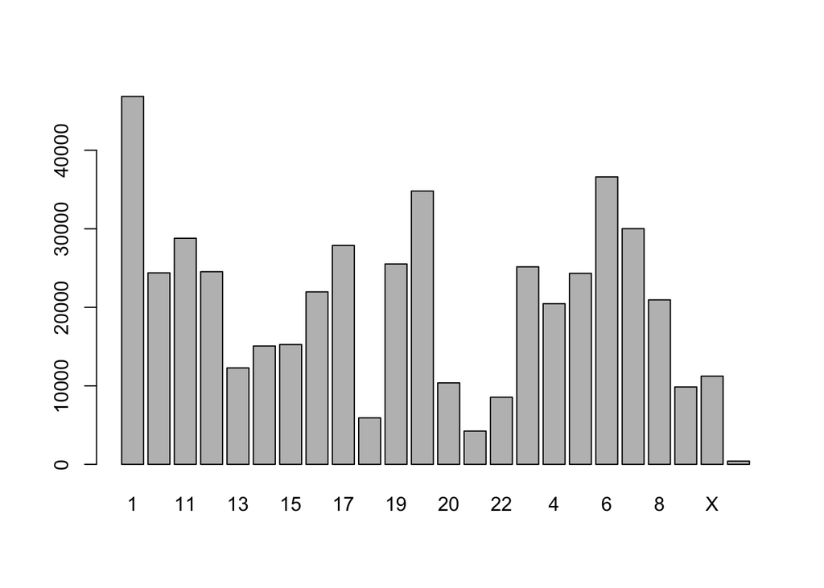

```r
counts <- table(Illumina450Manifest_clean$CHR)
barplot(counts)
```

```r
levels(Illumina450Manifest_clean$CHR)
```

```
##  [1] "1"  "10" "11" "12" "13" "14" "15" "16" "17" "18" "19" "2"  "20" "21" "22"
## [16] "3"  "4"  "5"  "6"  "7"  "8"  "9"  "X"  "Y"
```

R uses alphabetical order by default. I can reorder the levels of the chromosomes:

```r
Illumina450Manifest_clean$CHR <- factor(Illumina450Manifest_clean$CHR,levels=c("1","2","3","4","5","6","7","8","9","10","11","12","13","14","15","16","17","18","19","20","21","22","X","Y"))
levels(Illumina450Manifest_clean$CHR)
```

```
##  [1] "1"  "2"  "3"  "4"  "5"  "6"  "7"  "8"  "9"  "10" "11" "12" "13" "14" "15"
## [16] "16" "17" "18" "19" "20" "21" "22" "X"  "Y"
```

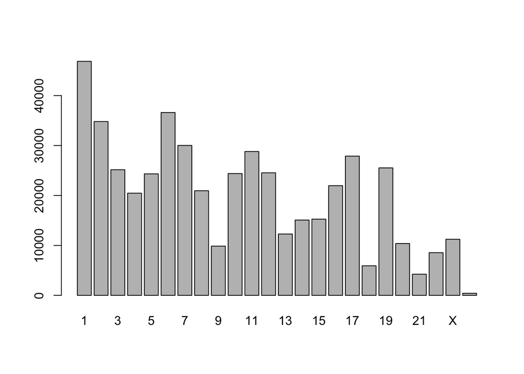

```r
barplot(table(Illumina450Manifest_clean$CHR))
```

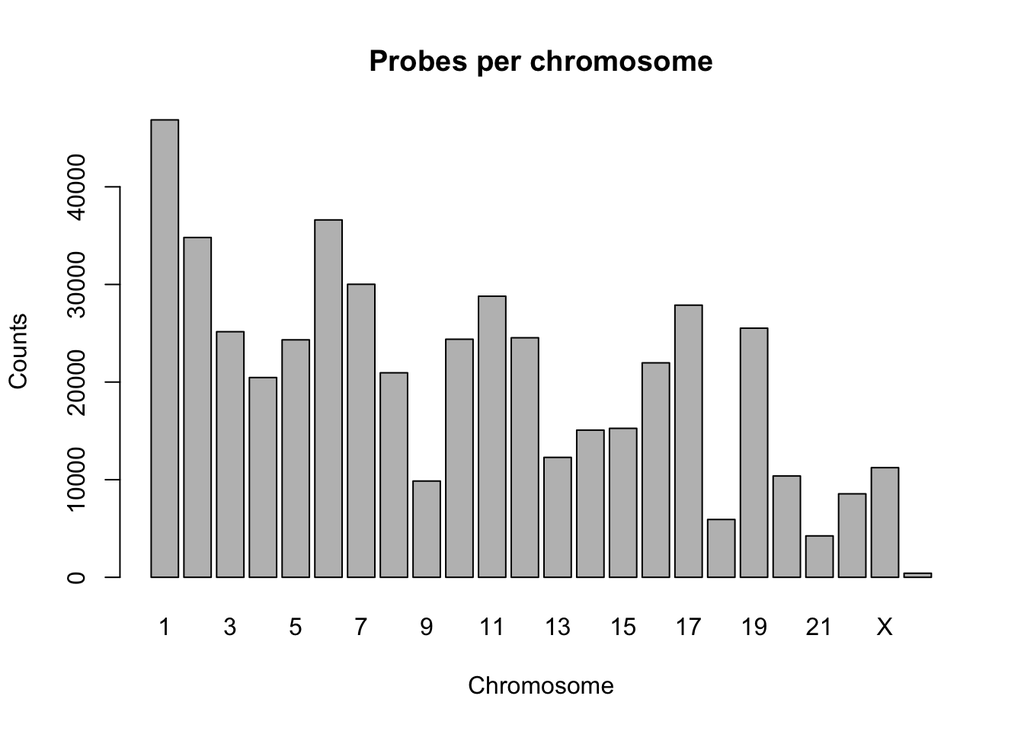

```r
barplot(table(Illumina450Manifest_clean$CHR),main="Probes per chromosome",xlab="Chromosome",ylab="Counts")
```

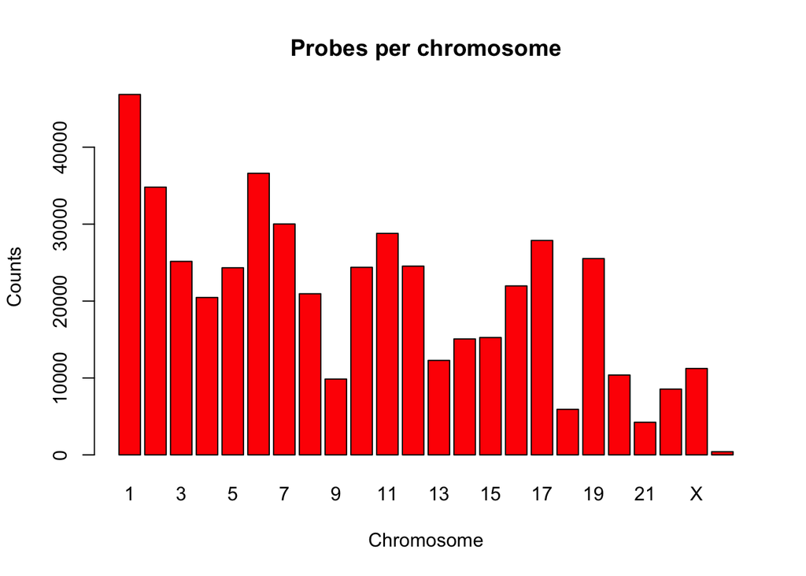

```r
barplot(table(Illumina450Manifest_clean$CHR),main="Probes per chromosome",xlab="Chromosome",ylab="Counts",col="red")
```

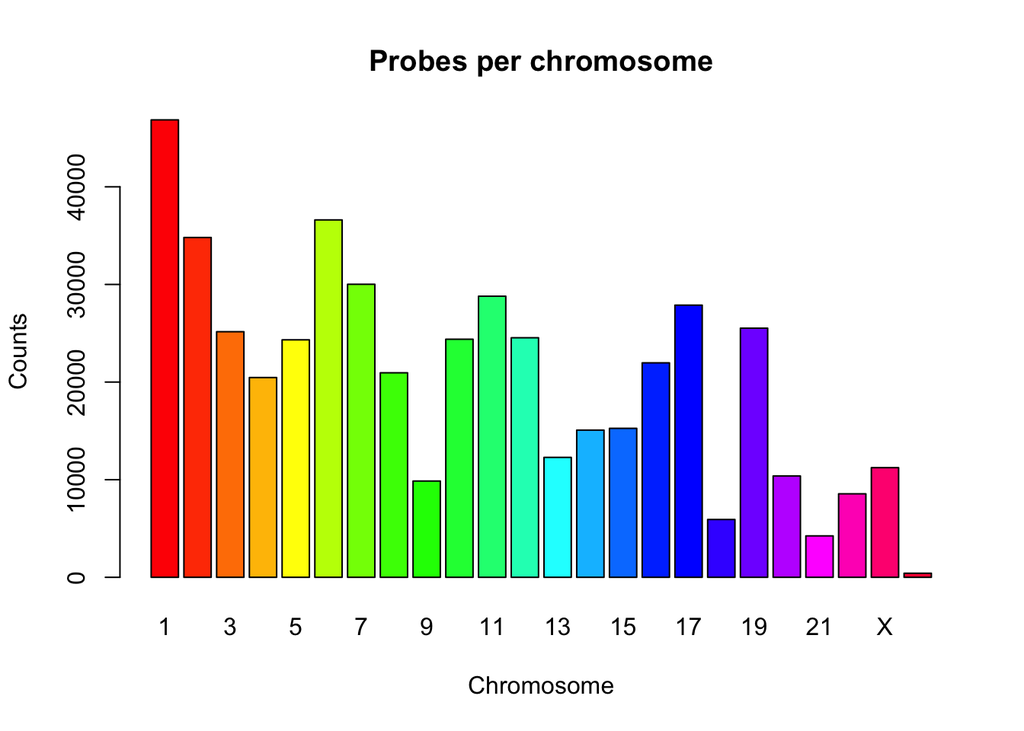

```r
barplot(table(Illumina450Manifest_clean$CHR),main="Probes per chromosome",xlab="Chromosome",ylab="Counts",col=rainbow(24))
```

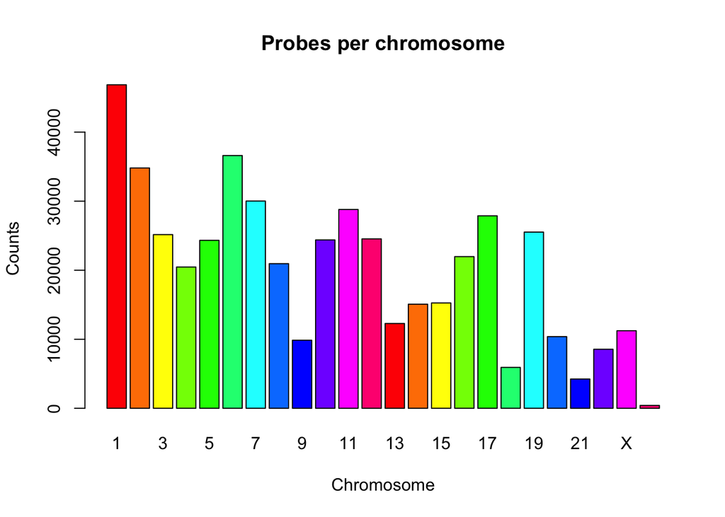

```r
barplot(table(Illumina450Manifest_clean$CHR),main="Probes per chromosome",xlab="Chromosome",ylab="Counts",col=rainbow(12))
```

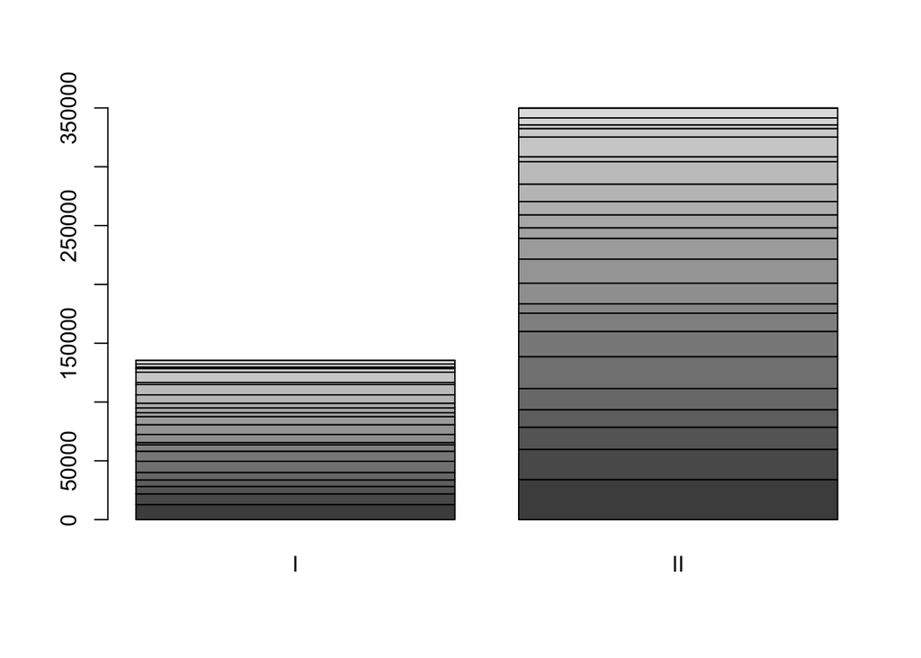

```r
barplot(table(Illumina450Manifest_clean$CHR, Illumina450Manifest_clean$Infinium_Design_Type))
```

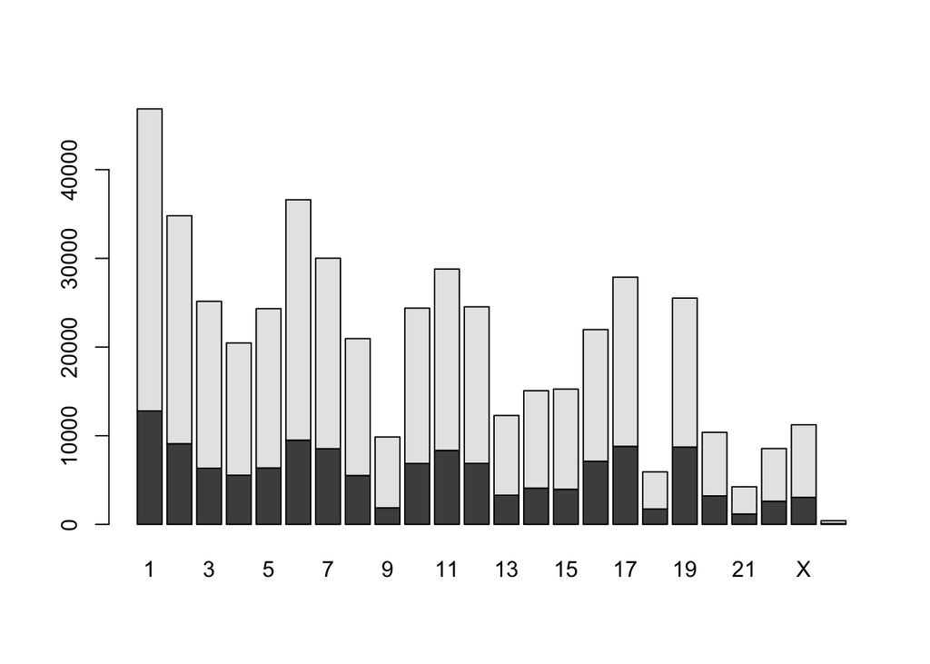

```r
barplot(table(Illumina450Manifest_clean$Infinium_Design_Type, Illumina450Manifest_clean$CHR))
```

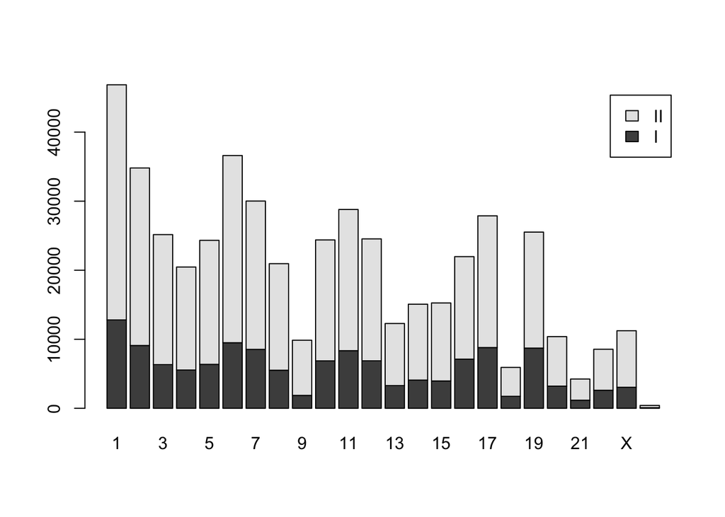

```r
barplot(table(Illumina450Manifest_clean$Infinium_Design_Type, Illumina450Manifest_clean$CHR), legend=levels(Illumina450Manifest_clean$Infinium_Design_Type))
```

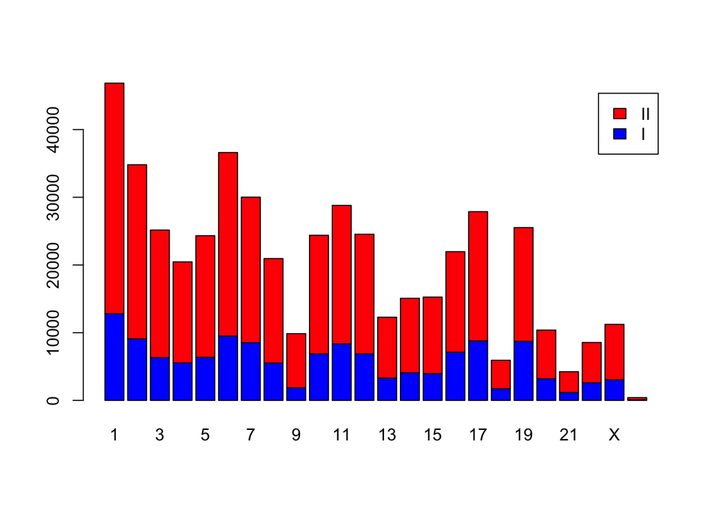

```r
barplot(table(Illumina450Manifest_clean$Infinium_Design_Type, Illumina450Manifest_clean$CHR), legend=levels(Illumina450Manifest_clean$Infinium_Design_Type),col=c("blue","red"))
```

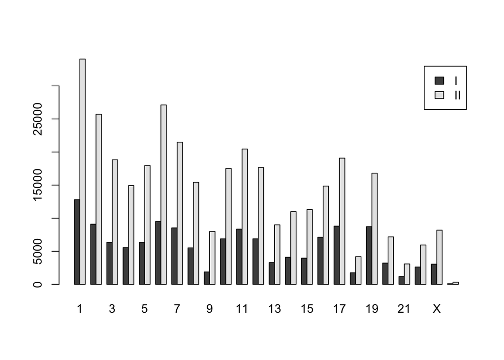

```r
barplot(table(Illumina450Manifest_clean$Infinium_Design_Type, Illumina450Manifest_clean$CHR),beside=T,legend=levels(Illumina450Manifest_clean$Infinium_Design_Type))
```

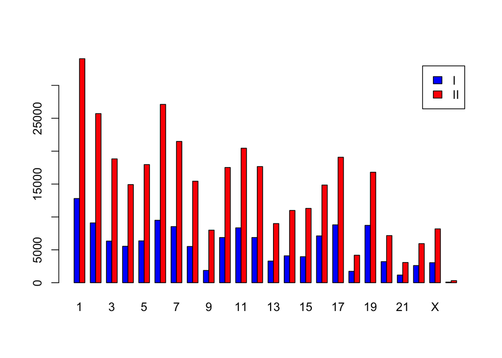

```r
barplot(table(Illumina450Manifest_clean$Infinium_Design_Type, Illumina450Manifest_clean$CHR),beside=T,legend=levels(Illumina450Manifest_clean$Infinium_Design_Type),col=c("blue","red"))
```

Exercise 5: Create a barplot representing the number of type I and II probes in each region (islands, shores, shelves and open sea)

Exercise 6: Load the Infinium27k manifest (the file Infinium27.txt): how many probes are in common between 27k and 450k? And where do the common probes map (Island, shore, shelves, genic or not genic)

# Supplementary

Is the ratio between typeI and typeII constant between the chromosomes?

```r
table(Illumina450Manifest_clean$Infinium_Design_Type, Illumina450Manifest_clean$CHR)
```

```
##
##          1     2     3     4     5     6     7     8     9    10    11    12
##   I  12800  9096  6331  5544  6365  9497  8534  5513  1866  6869  8343  6876
##   II 34057 25714 18828 14920 17962 27114 21483 15437  7995 17519 20451 17663
##
##         13    14    15    16    17    18    19    20    21    22     X     Y
##   I   3291  4090  3957  7118  8798  1740  8720  3210  1168  2610  3045    95
##   II  8994 10988 11302 14851 19081  4182 16801  7169  3075  5942  8187   321
```

```r
df_table <- data.frame(table(Illumina450Manifest_clean$Infinium_Design_Type, Illumina450Manifest_clean$CHR))
df_table
```

```
##    Var1 Var2  Freq
## 1     I    1 12800
## 2    II    1 34057
## 3     I    2  9096
## 4    II    2 25714
## 5     I    3  6331
## 6    II    3 18828
## 7     I    4  5544
## 8    II    4 14920
## 9     I    5  6365
## 10   II    5 17962
## 11    I    6  9497
## 12   II    6 27114
## 13    I    7  8534
## 14   II    7 21483
```

[output cut: 34 more lines]

```r
df_table_I <- df_table[df_table$Var1=="I",]
df_table_I <- droplevels(df_table_I)
df_table_II <- df_table[df_table$Var1=="II",]
df_table_II <- droplevels(df_table_II)
head(df_table_I)
```

```
##    Var1 Var2  Freq
## 1     I    1 12800
## 3     I    2  9096
## 5     I    3  6331
## 7     I    4  5544
## 9     I    5  6365
## 11    I    6  9497
```

```r
head(df_table_II)
```

```
##    Var1 Var2  Freq
## 2    II    1 34057
## 4    II    2 25714
## 6    II    3 18828
## 8    II    4 14920
## 10   II    5 17962
## 12   II    6 27114
```

Let’s check that the order of the chromosomes is the same in df_table_I and df_table_II

```r
df_table_I[,2]==df_table_II[,2]
```

```
##  [1] TRUE TRUE TRUE TRUE TRUE TRUE TRUE TRUE TRUE TRUE TRUE TRUE TRUE TRUE TRUE
## [16] TRUE TRUE TRUE TRUE TRUE TRUE TRUE TRUE TRUE
```

```r
table(df_table_I[,2]==df_table_II[,2])
```

```
##
## TRUE
##   24
```

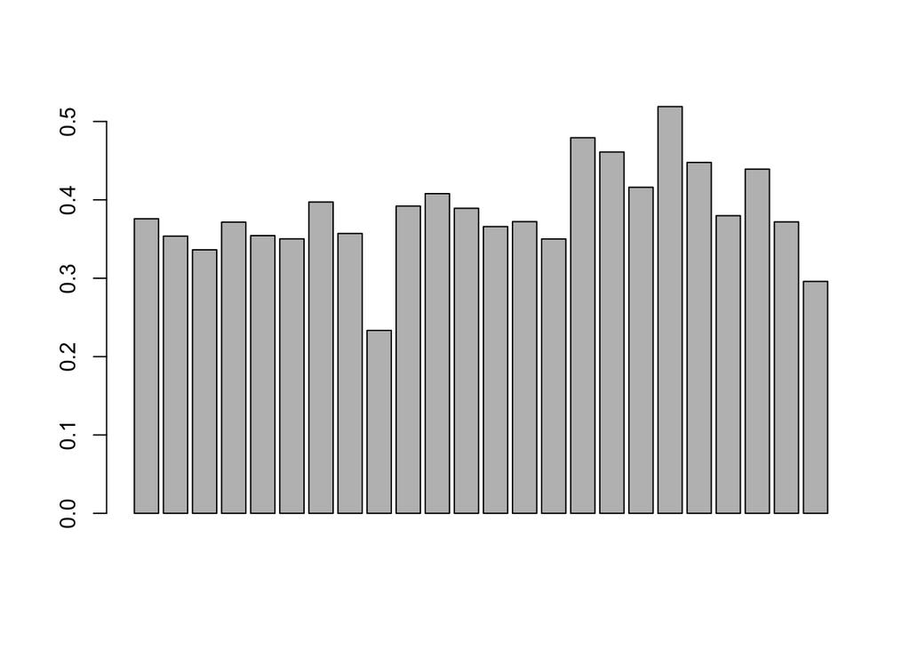

```r
ratio_I_II <- df_table_I[,3]/df_table_II[,3]
barplot(ratio_I_II)
```

```r
ratio_I_II
```

```
##  [1] 0.3758405 0.3537373 0.3362545 0.3715818 0.3543592 0.3502619 0.3972443
##  [8] 0.3571290 0.2333959 0.3920886 0.4079507 0.3892883 0.3659106 0.3722242
## [15] 0.3501150 0.4792943 0.4610869 0.4160689 0.5190167 0.4477612 0.3798374
## [22] 0.4392460 0.3719311 0.2959502
```

ratio_I_II is jus a vector, without names. If I want to add the chromosome names to the plots

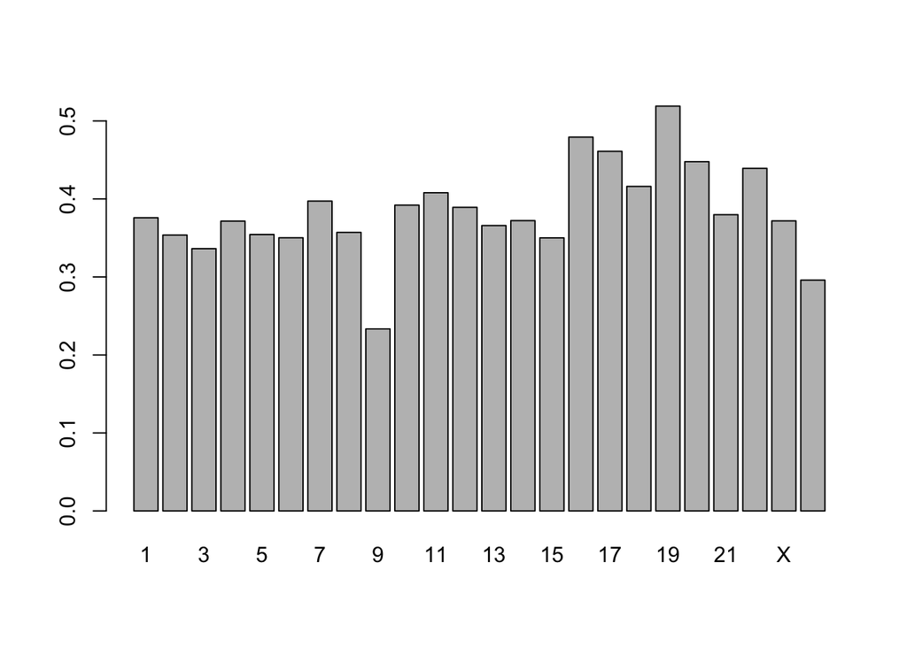

```r
barplot(ratio_I_II,names.arg=levels(df_table_I$Var2))
```

or, in alternative:

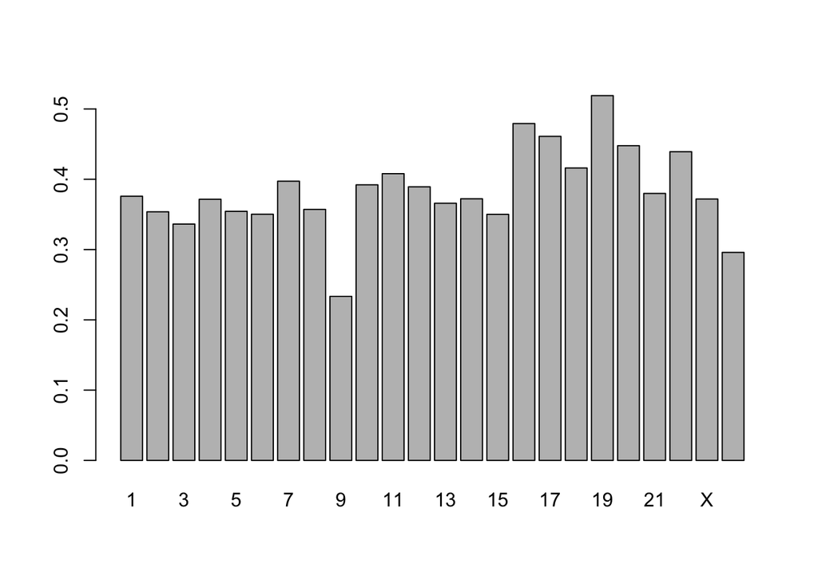

```r
names(ratio_I_II) <- levels(df_table_I$Var2)
barplot(ratio_I_II)
```